# Problem 1 - Classifying Sensor Data

```python
import numpy as np
import pandas as pd
import utils
```

## Read Data

```python
train, test, scl, select_cols = utils.load_and_process_data()
```

```
Reading files
Converting files to pandas DataFrames
Preprocessing data
Scaling data
```

```python
train.head(10)
```

|  | LABEL | SENSOR_A | SENSOR_B | TIME | container_id | measurement_id | time_diff1 | time_diff2 | time_diff3 | time_diff4 | y | SENSOR_A_scl | SENSOR_B_scl | time_diff1_scl | time_diff2_scl | time_diff3_scl | time_diff4_scl |
| --- | --- | --- | --- | --- | --- | --- | --- | --- | --- | --- | --- | --- | --- | --- | --- | --- | --- |
| 0 | UNLOAD_SHIP | -157 | 33 | 2016-01-01 07:04:03.259405 | 0 | 0 | 100355.268036 | 194421.313503 | 256931.428213 | 315232.147239 | 0 | -1.314738 | 0.590921 | 0.000000 | 0.000000 | 7.519569e-16 | 0.000000 |
| 1 | LOAD_TRAIN | 103 | -32 | 2016-01-04 09:40:37.897263 | 0 | 1 | 268594.000000 | 194421.313503 | 256931.428213 | 315232.147239 | 1 | 0.865751 | -0.382093 | 2.218199 | 0.000000 | 7.519569e-16 | 0.000000 |
| 2 | NOISE | 77 | -20 | 2016-01-04 21:26:00.897263 | 0 | 2 | 42323.000000 | 310917.000000 | 256931.428213 | 315232.147239 | 2 | 0.647702 | -0.202459 | -0.765146 | 1.307070 | 7.519569e-16 | 0.000000 |
| 3 | DEPART_TRAIN | -38 | -56 | 2016-01-05 05:44:02.396489 | 0 | 3 | 29881.000000 | 72204.000000 | 340799.000000 | 315232.147239 | 3 | -0.316745 | -0.741360 | -0.929191 | -1.371266 | 1.083445e+00 | 0.000000 |
| 4 | NOISE | 49 | 105 | 2016-01-06 03:10:44.396489 | 0 | 4 | 77202.000000 | 107083.000000 | 149406.000000 | 418001.000000 | 2 | 0.412880 | 1.668722 | -0.305272 | -0.979927 | -1.389070e+00 | 1.813944 |
| 5 | UNLOAD_SHIP | -267 | 58 | 2015-06-28 19:17:05.385260 | 1 | 0 | 100355.268036 | 194421.313503 | 256931.428213 | 315232.147239 | 0 | -2.237252 | 0.965158 | 0.000000 | 0.000000 | 7.519569e-16 | 0.000000 |
| 6 | LOAD_TRAIN | 93 | 35 | 2015-07-01 21:33:34.377683 | 1 | 1 | 267388.000000 | 194421.313503 | 256931.428213 | 315232.147239 | 1 | 0.781886 | 0.620860 | 2.202298 | 0.000000 | 7.519569e-16 | 0.000000 |
| 7 | DEPART_TRAIN | -23 | 82 | 2015-07-02 16:23:50.373709 | 1 | 2 | 67815.000000 | 335204.000000 | 256931.428213 | 315232.147239 | 3 | -0.190947 | 1.324424 | -0.429038 | 1.579567 | 7.519569e-16 | 0.000000 |
| 8 | NOISE | 95 | 29 | 2015-02-27 00:20:33.560899 | 2 | 0 | 100355.268036 | 194421.313503 | 256931.428213 | 315232.147239 | 2 | 0.798659 | 0.531044 | 0.000000 | 0.000000 | 7.519569e-16 | 0.000000 |
| 9 | NOISE | 87 | -70 | 2015-02-28 15:59:08.560899 | 2 | 1 | 142715.000000 | 194421.313503 | 256931.428213 | 315232.147239 | 2 | 0.731567 | -0.950932 | 0.558506 | 0.000000 | 7.519569e-16 | 0.000000 |

## EDA

#### Visualize the distribution of sensor data with targets

#### => The distribution of Unload Ship is completely separable from the rest using Sensor A

#### => The distribution of Noise overlaps the distributions of Load Train and Depart Train

#### => The distributions of Load Train and Depart Train do not really overlap

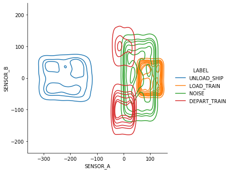

```python
utils.plot_2d_kde(x='SENSOR_A',
                  y='SENSOR_B',
                  hue='LABEL',
                  data=train)
```

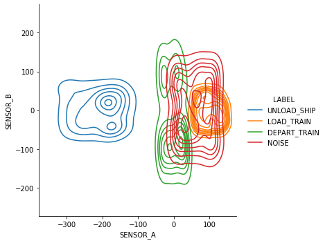

```python
utils.plot_2d_kde(x='SENSOR_A',
                  y='SENSOR_B',
                  hue='LABEL',
                  data=test)
```

#### Visualize sensor data over time to check for seasonal trends

#### => There are none

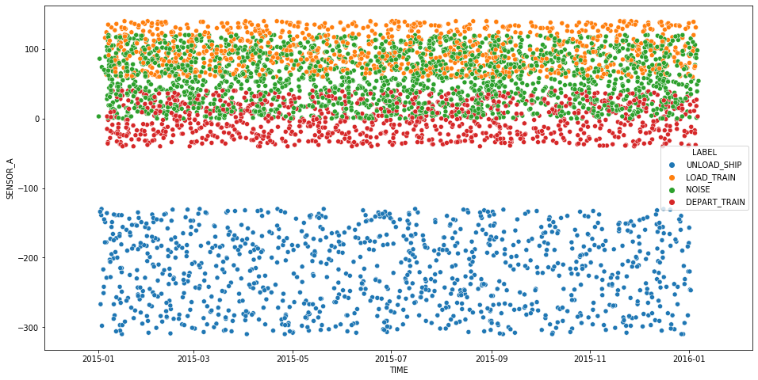

```python
utils.plot_time_series(x='TIME',
                       y='SENSOR_A',
                       hue='LABEL',
                       data=train)
```

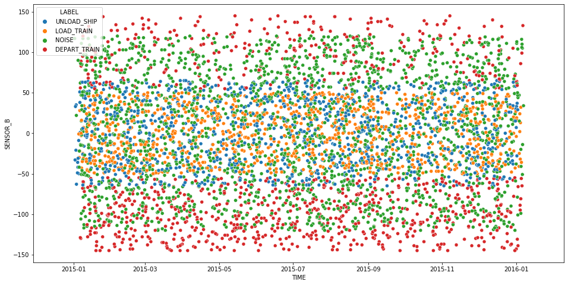

```python
utils.plot_time_series(x='TIME',
                       y='SENSOR_B',
                       hue='LABEL',
                       data=train)
```

#### Visualize distributions of first 2 time difference features

#### => They provide strong information about 3 of the labels

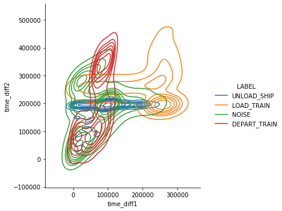

```python
utils.plot_2d_kde(x='time_diff1',
                  y='time_diff2',
                  hue='LABEL',
                  data=train)
```

#### Visualize distributions of last 2 time difference features

#### => They provide information to help distinguish Noise

#### => Information about Unload Ship and Load Train is largely lost since these should be the first two labels for every container. The distributions are collapsed to the mean.

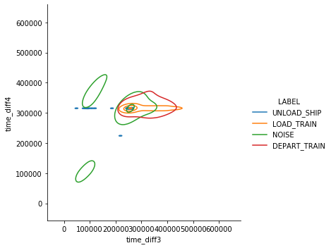

```python
utils.plot_2d_kde(x='time_diff3',
                  y='time_diff4',
                  hue='LABEL',
                  data=train)
```

## Train model

#### Based on the uniform distributions of the labels in rectangular grids across the space of the sensor data, a tree-based model is an appropriate choice since they make discrete splits based on feature values

#### Use a simple XGBClassifier

```python
params = {'max_depth': 7,
          'n_estimators': 1000,
          'num_classes': train.y.max() + 1}
clf, train_pred, train_probs, test_pred, test_probs = utils.fit_predict(train, test, select_cols, params)
```

```
Confusion Matrix

[[100   0   0   0]
 [  0  97   3   0]
 [  0   3 184   2]
 [  0   0   3  97]]

Accuracy: 0.98

Micro Precision: 0.98
Micro Recall: 0.98
Micro F1-score: 0.98

Macro Precision: 0.98
Macro Recall: 0.98
Macro F1-score: 0.98

Weighted Precision: 0.98
Weighted Recall: 0.98
Weighted F1-score: 0.98

Classification Report

              precision    recall  f1-score   support

 UNLOAD_SHIP       1.00      1.00      1.00       100
  LOAD_TRAIN       0.97      0.97      0.97       100
       NOISE       0.97      0.97      0.97       189
DEPART_TRAIN       0.98      0.97      0.97       100

    accuracy                           0.98       489
   macro avg       0.98      0.98      0.98       489
weighted avg       0.98      0.98      0.98       489
```

#### Check if every container has all 3 necessary labels

```python
train['pred'] = train_pred
test['pred'] = test_pred
```

```python
train_container_pred = train.groupby('container_id')['pred'].unique().to_list()
test_container_pred = test.groupby('container_id')['pred'].unique().to_list()
train_failed_3_labels = [ind for ind, item in enumerate(train_container_pred) if not set([0, 1, 3]).issubset(set(list(item)))]
test_failed_3_labels = [ind for ind, item in enumerate(test_container_pred) if not set([0, 1, 3]).issubset(set(list(item)))]
```

```python
train_failed_3_labels
```

```
[]
```

```python
test_failed_3_labels
```

```
[34, 44, 51, 52, 76]
```

#### Check if every container has all 3 labels in order, and no extra labels

```python
train_failed_order = [[i for i in item if i != 2] for item in train_container_pred]
train_failed_order = [ind for ind, item in enumerate(train_failed_order) if item != [0, 1, 3]]
test_failed_order = [[i for i in item if i != 2] for item in test_container_pred]
test_failed_order = [ind for ind, item in enumerate(test_failed_order) if item != [0, 1, 3]]
```

```python
train_failed_order
```

```
[]
```

```python
test_failed_order
```

```
[34, 44, 51, 52, 76]
```

#### None of the containers in train, but 5 containers in the test set are missing a necessary label

## Issues with the model

#### => The model does not have any constraints on presence of all 3 labels for each container_id

#### => The model does not have any constraints on sequential nature of labels

#### => Create process that uses a series of one-vs-one (binary classification) and one-vs-rest models

The process for this series of models is as follows:

1. Fit a one-vs-rest model to predict the first label in the series, `'Unload Ship'` or `'Rest'`. In this case, the first label can only be `'Noise'` or `'Unload Ship'`, so this is a standard binary classification model.
2. Store the predictions, and keep track of the point at which each container has received a positive prediction for that class.
3. Keep all rows for a container after the point at which the model has predicted the positive class. This immitates the production process of continuing to pass container updates through the first model until it predicts `'Unload Ship'`, and then moving on to only predict the next labels for that container. It also prevents future models from seeing data that they would not have access to in a production environment.
4. Repeat Steps 1 through 3 for the remaining labels. This ensures that every container receives every label in order, and that its measurements will keep getting passed through the models until it receives a positive prediction for each label.

```python
train, test, scl_dict, model_dict = utils.ovr_model_series(train, test, select_cols)
```

```
OVR Model performance for UNLOAD_SHIP

----------------
Confusion Matrix

[[389   0]
 [  0 100]]

Accuracy: 1.00

Micro Precision: 1.00
Micro Recall: 1.00
Micro F1-score: 1.00

Macro Precision: 1.00
Macro Recall: 1.00
Macro F1-score: 1.00

Weighted Precision: 1.00
Weighted Recall: 1.00
Weighted F1-score: 1.00

Classification Report

              precision    recall  f1-score   support

        Rest       1.00      1.00      1.00       389
 UNLOAD_SHIP       1.00      1.00      1.00       100

    accuracy                           1.00       489
   macro avg       1.00      1.00      1.00       489
weighted avg       1.00      1.00      1.00       489
```

```
OVR Model performance for LOAD_TRAIN

----------------
Confusion Matrix

[[234   3]
 [  3  97]]

Accuracy: 0.98

Micro Precision: 0.98
Micro Recall: 0.98
Micro F1-score: 0.98

Macro Precision: 0.98
Macro Recall: 0.98
Macro F1-score: 0.98

Weighted Precision: 0.98
Weighted Recall: 0.98
Weighted F1-score: 0.98

Classification Report

              precision    recall  f1-score   support

        Rest       0.99      0.99      0.99       237
  LOAD_TRAIN       0.97      0.97      0.97       100

    accuracy                           0.98       337
   macro avg       0.98      0.98      0.98       337
weighted avg       0.98      0.98      0.98       337
```

```
OVR Model performance for DEPART_TRAIN

----------------
Confusion Matrix

[[85  2]
 [ 2 94]]

Accuracy: 0.98

Micro Precision: 0.98
Micro Recall: 0.98
Micro F1-score: 0.98

Macro Precision: 0.98
Macro Recall: 0.98
Macro F1-score: 0.98

Weighted Precision: 0.98
Weighted Recall: 0.98
Weighted F1-score: 0.98

Classification Report

              precision    recall  f1-score   support

        Rest       0.98      0.98      0.98        87
DEPART_TRAIN       0.98      0.98      0.98        96

    accuracy                           0.98       183
   macro avg       0.98      0.98      0.98       183
weighted avg       0.98      0.98      0.98       183

Total OVR Model performance
----------------
Confusion Matrix

[[100   0   0   0]
 [  0  97   3   0]
 [  0   3 184   2]
```

[output cut: 13 more lines]

```
Weighted Recall: 0.97
Weighted F1-score: 0.97

Classification Report

              precision    recall  f1-score   support

 UNLOAD_SHIP       1.00      1.00      1.00       100
  LOAD_TRAIN       0.97      0.97      0.97       100
       NOISE       0.95      0.97      0.96       189
DEPART_TRAIN       0.98      0.94      0.96       100

    accuracy                           0.97       489
   macro avg       0.98      0.97      0.97       489
weighted avg       0.97      0.97      0.97       489
```

#### Check if every container has all 3 necessary labels

```python
train_container_pred = train.groupby('container_id')['ovr_pred'].unique().to_list()
test_container_pred = test.groupby('container_id')['ovr_pred'].unique().to_list()
train_failed_3_labels = [ind for ind, item in enumerate(train_container_pred) if not set([0, 1, 3]).issubset(set(list(item)))]
test_failed_3_labels = [ind for ind, item in enumerate(test_container_pred) if not set([0, 1, 3]).issubset(set(list(item)))]
```

```python
train_failed_3_labels
```

```
[]
```

```python
test_failed_3_labels
```

```
[9, 34, 44, 52, 76, 88]
```

#### Check if every container has all 3 labels in order, and no extra labels

```python
train_failed_order = [[i for i in item if i != 2] for item in train_container_pred]
train_failed_order = [ind for ind, item in enumerate(train_failed_order) if item != [0, 1, 3]]
test_failed_order = [[i for i in item if i != 2] for item in test_container_pred]
test_failed_order = [ind for ind, item in enumerate(test_failed_order) if item != [0, 1, 3]]
```

```python
train_failed_order
```

```
[]
```

```python
test_failed_order
```

```
[9, 34, 44, 52, 76, 88]
```

#### 6 containers in the test set do not have all three labels

## Discussion

Overall, the single multiclass classification model performs just slightly better than the series of one-vs-rest binary classification models. I believe this is due to both previous model error passing through to future models, and to the smaller sample sizes as the input data gets filtered before the next model. By the final model for the `'Depart Train'` label, the data has much fewer examples of `'Noise'` to be able to distinguish the two. Since the distribution of Noise does not vary with time, it could be argued that this training data does not need to be filtered out for the next model, however this is not always the case.

Though there were no examples in the single model approach where a container's labels were predicted in an impossible order, it would not be robust enough to deploy in a production environment. Despite its slightly worse performance, I would advocate for deploying the series of one-vs-rest models so that this would not be a concern.

When I created the logic for the series of models, I believed that it would prevent containers from not receiving all 3 labels. However, this was not the case, and I don't have time to remedy that bug.

As far as impact to ClearMetal's business, False Positives (FP) are a worse outcome than False Negatives (FN). In the FP case, ClearMetal would notify a customer that the shipment has progressed to the next step, when that was not the case. This could cause the customer to update their warehouse/trucker schedules in anticipation of an arrival, and incur unnecessary costs. In the False Negative case, the update provided to them would simply be later than normal, which in the absence of ClearMetal's insightful platform would be a business-as-usual case. Going forward, the models should be tuned to reflect the higher costs of FP, and aimed at improving Precision.

Future work could use a directed graph approach to incorporate the sequential nature of the labels in the modeling process. Sticking with the OVR model series approach, every observation could be passed through every OVR model, and then use the graph to identify which label should be assigned to each update based on the predicted probabilities for each class of every container update that the model has seen.

Another step to enhance the model would be to perform hyperparameter tuning and to evaluate different model types, although since I achieved an F1 Score of about 0.98 I decided that was good enough for this problem. In my past experience with hyperparameter tuning, I have used `hyperopt`, a Bayesian hyperparameter tuning framework. In that framework, prior distributions are assigned to the hyperparameter values, and then the model samples from those to train. The model updates the corresponding posterior distributions based on the results that achieve lower loss, and then samples from those for the next training iteration. This is a much less computationally-expensive approach to hyperparameter tuning then random search or grid search, and is more likely to achieve a stronger model.

# Problem 2 - Reconciling conflicting data

My first step would be to try and establish some baseline for the amount of time it takes for a container to move through each route and method of transport. This could be informed by Google Maps' API for drive times of getting from point A to point B if it is a land route, or by cargo ship route times using satellite data for sea routes. Once this is acquired, historical route times across a variety of carriers would also help establish the baseline. The first step gives some sense of how long a route *should* take, and the second step gives the distribution of how long the routes are reported take according to the various parties. The distribution in the second step could actually be computed as the distribution of the difference between how long the transporter reported the trip to take and how long the recipient of the container reported it to take, and the mean of that distribution should be close to the route time from the first step.

By looking at this distribution for various transporters and recipients, it should become apparent if there are any systematic differnces in how the trip time is being reported. Using the example in the background, if a port is not technologically savvy and consistently reports the receipt of the containers late, then the distribution for any transporter and that port would be skewed in that direction. Obviously, if a port always reports the receipt late, and the transporter knows this, they can always report late and ClearMetal would be none the wiser. That is why it would be critical to get this historical information across a variety of transporters if possible. Even if this is not possible, I think the likelihood that every single driver/conductor having the knowledge and the desire to game the system in this way is low.

I would use two main statistical models for this problem. The first would be a classification model to decide whether or not a particular reported event is valid. This would probably require manually labeling data based on known examples, and these labels would vary by region, so I acknowledge that it would be no small task. Features I would look to include would be the baseline route time using Google Maps/satellite data, the reported route time according to the event, statistics from the historical reported route times of the transporter and those of other transporters, and statistics from the historical reported route times of the receiver. I would also look to give it information from past events for the same container logged by other parties, to give the model some information about if the reported route time is physically possible. Then, the reported time with the highest likelihood of being correct would be taken as the correct event

The second model would be another classification model - very similar to the first - but which contains information from future events. This would be part of a process to retroactively assess the likelihood that past events were reported incorrectly given more information from the future, and improve the performance of the first model. If information from future events informs us that a past event time should be updated, this should absolutely be corrected in order to give ClearMetal's customers the most accurate information to plan around.

Since in reality all reports for a single event could be incorrect, an alternative approach would be to use a regression model to estimate the actual event time, taking into account the features described in the classification approach. In this way, the process is not bound to using any of the event times reported by the involved parties. A similar alternative would be to use the predicted probabilities over the reports to create a weighted average of the most likely event time, turning the one model into a kind of ensemble approach. All of these approaches would have to be compared against some ground truth value in the end, making the manual labeling a critical step in the process.